# Visual Inference

## What You Will Need

We can use the inferviz package to do some interesting things:

```r
devtools::install_github("saberry/inferviz")
```

## Apophenia

It’s a real thing and it does have good uses.

[figure not shown]

Without regard to the visual component, it can have great use in storytelling.

## Testing Hypotheses

We have talked about the purposes of visualization: exploration and inference. When we are thinking about inference in a visual sense, we tend to think about seeing patterns that support our hypotheses. In the coming weeks, we are going to talk about statistical models that assist in inference. We can also create inferential tests (think *p*-values) with visualization.

## An Easy One

### Hypotheses

Let’s generate a hypothesis about our good old mtcars data.

For one, we might say that we would anticipate that as horsepower increases, the number of miles per gallon decreases. This seems like a reasonable proposition and one that we can test with visual inference.

### Inferential Strength

Consider the following:

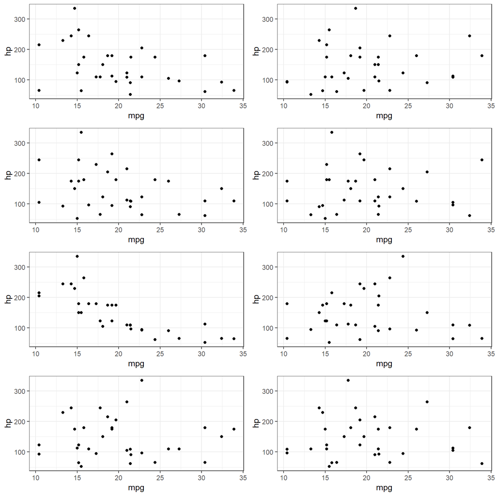

```r
inferviz::simViz(mtcars, mpg, hp,
                 distractors = 7, answer = FALSE)
```

### Reality

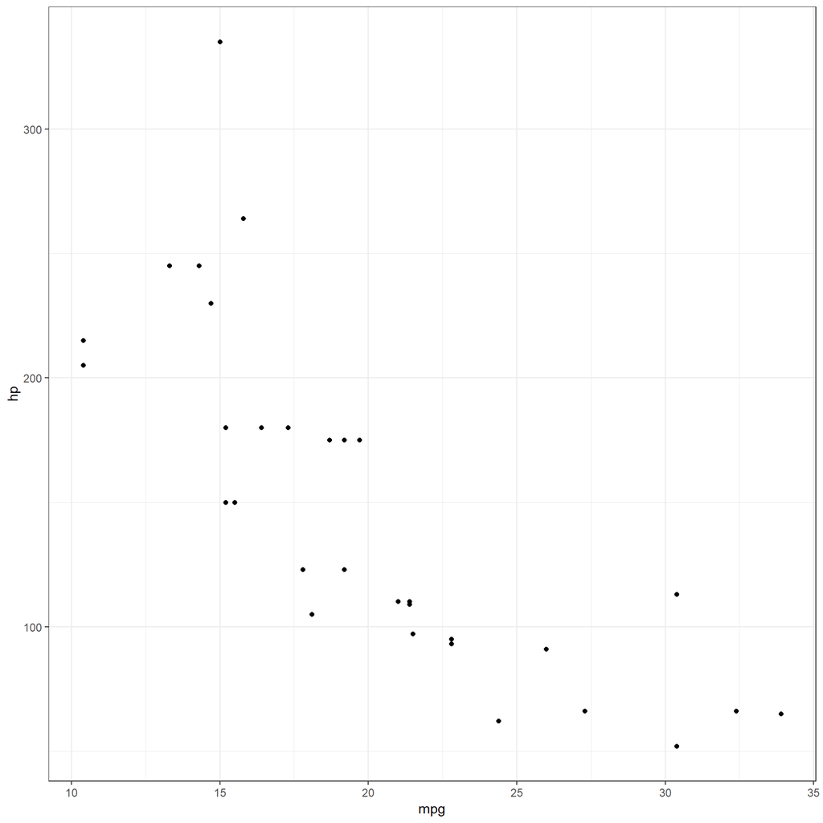

```r
library(ggplot2)

ggplot(mtcars, aes(mpg, hp)) +
  geom_point() +
  theme_bw()
```

## More Challenging

Let’s maybe consider some more challenging data.

```r
library(rsample)

data("attrition")
```

### Inference

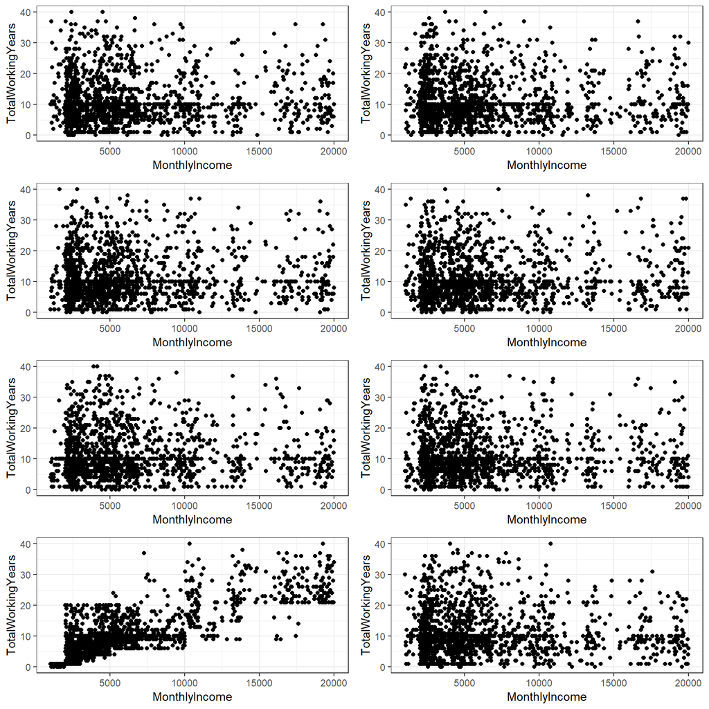

```r
inferviz::simViz(attrition, MonthlyIncome, TotalWorkingYears,
                 distractors = 7, answer = FALSE)
```

### Reality

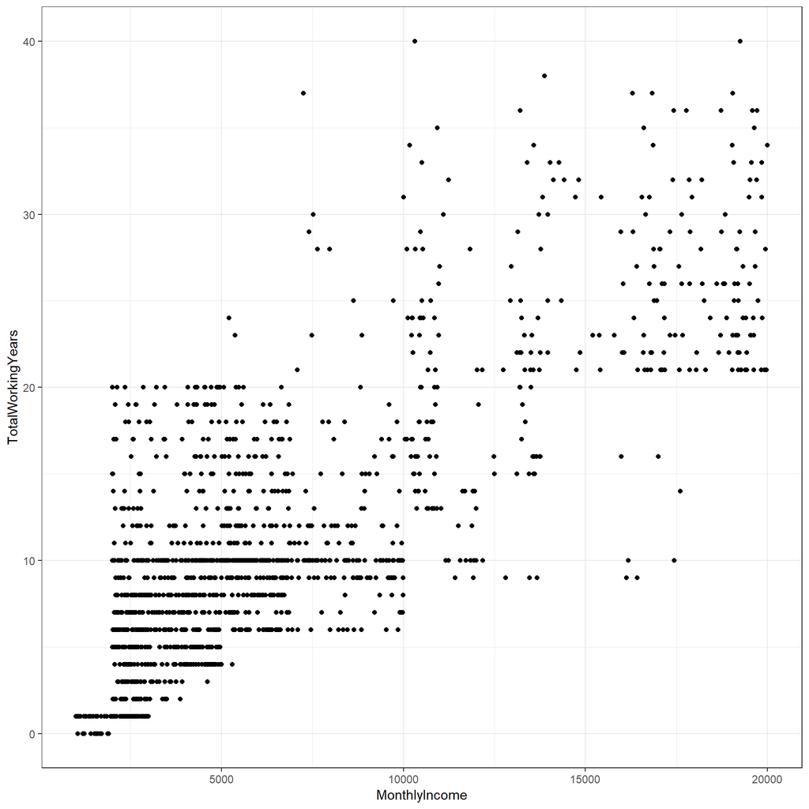

```r
ggplot(attrition, aes(MonthlyIncome, TotalWorkingYears)) +
  geom_point() +
  theme_bw()
```

## One Final Example

Now, let’s use some hedge fund data:

```r
hedgeData = read.csv("http://www.nd.edu/~sberry5/data/hedgeFundTest.csv")
```

### Hypothesis

When we look at our data, we see a few variables:

```r
names(hedgeData)
```

```
## [1] "FundID"      "fund_assets" "nav"         "vendorVal"
```

Let’s propose that as the net asset value (nav) goes up, a vendor’s valuation will also go up (vendorVal).

### Inference

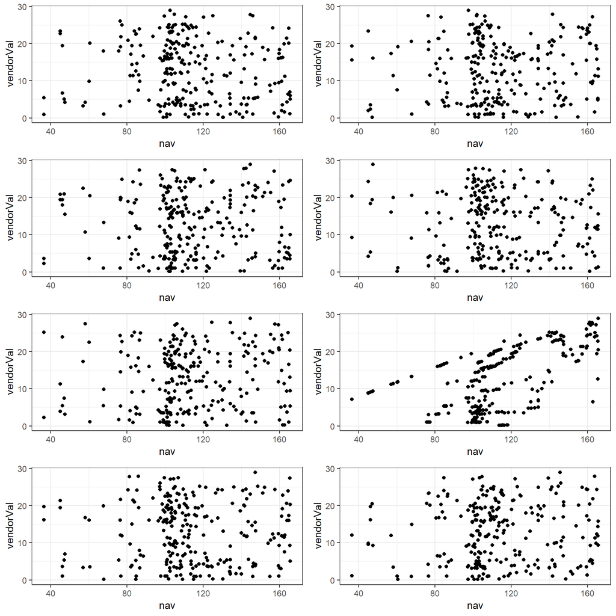

```r
inferviz::simViz(hedgeData, nav, vendorVal,
                 distractors = 7, answer = FALSE)
```

### Reality

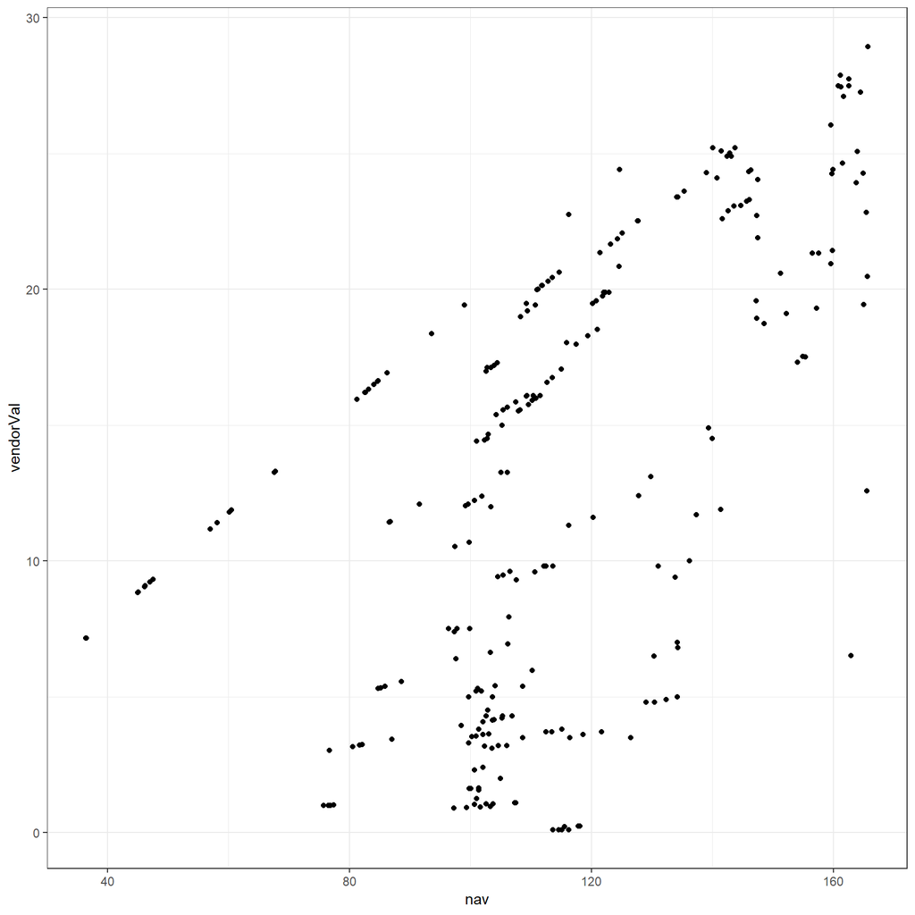

```r
ggplot(hedgeData, aes(nav, vendorVal)) +
  geom_point() +
  theme_bw()
```